# Summary report for Chard

UKMON

2017-07-18

# Summary of activity in 2017

Chard operates 1 cameras.

In 2017 Chard has recorded 110 individual meteor observations. These observations comprise 19 sporadic meteors and 91 stream meteors. A breakdown by month is shown below.

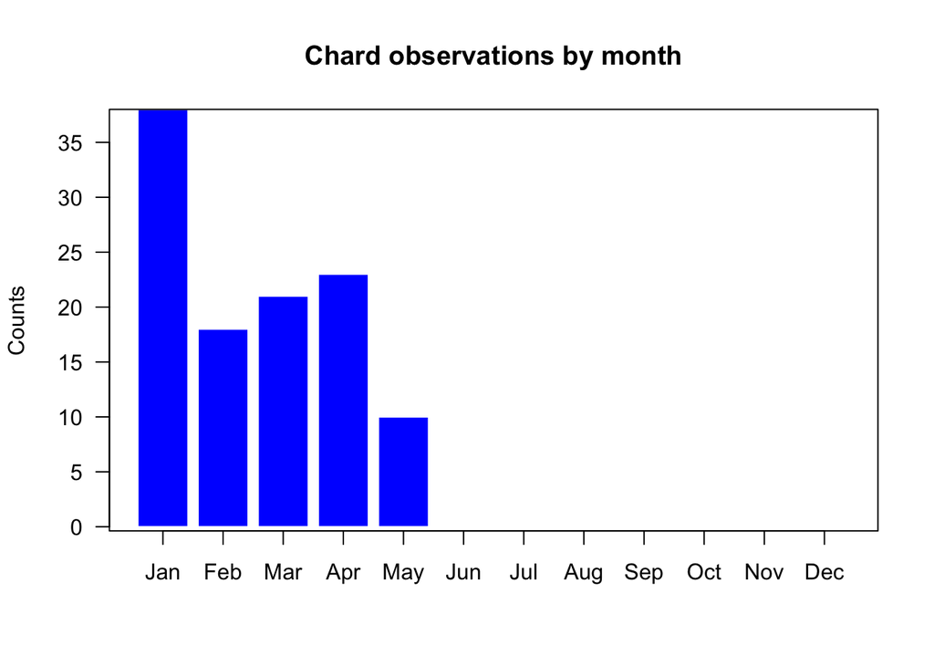

The following shows observation counts by stream for the 20 most frequent showers based on preliminary UFO ANALYSIS classifications:

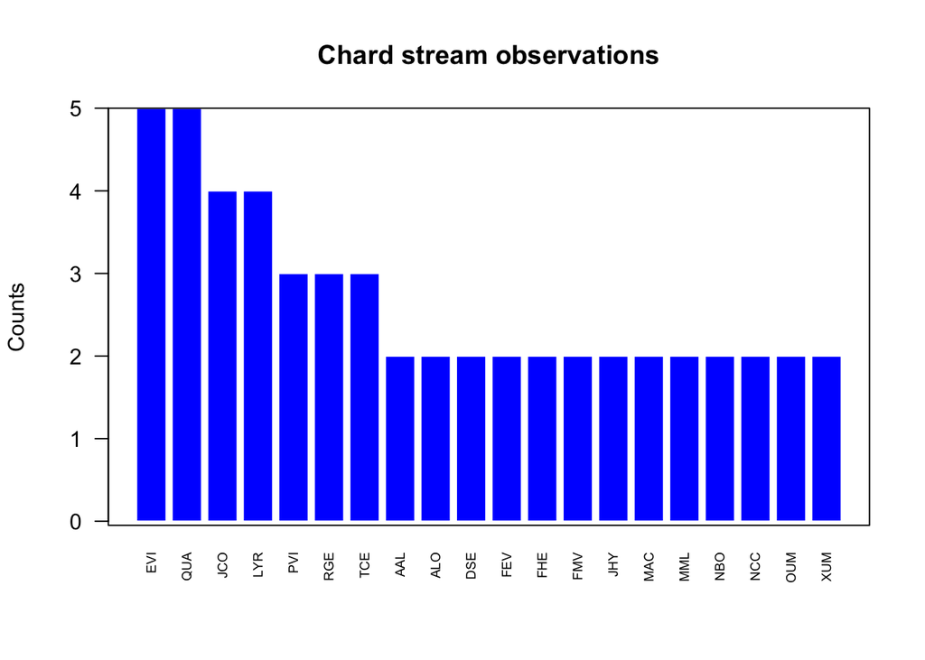

The following table shows which stations are generating matched observations with this station and the number of matches:

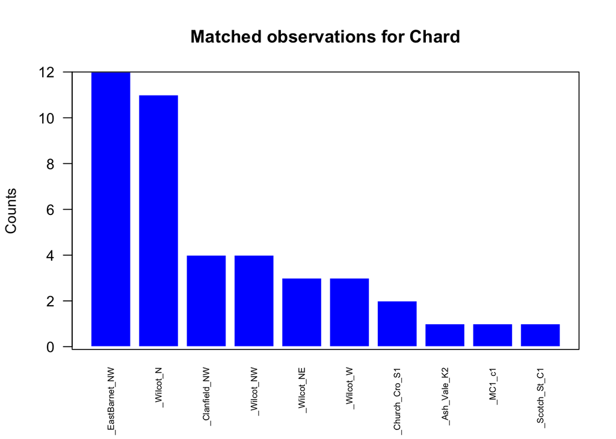

# Observations recorded by Chard, 2016 to 2017

UKMON data for Chard covers the period from 2016 to 2017 and totals 283 individual meteor observations. These observations comprise 30 sporadic meteors and 253 stream meteors.

This section provides a summary of all observations by Chard from 2016 to 2017. A breakdown of the number of observations by year is given in the histogram below.

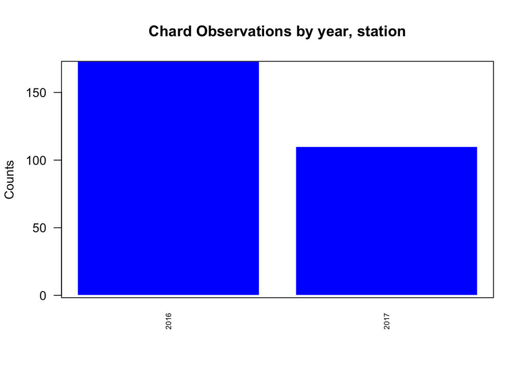

The following graph shows observation counts by stream (preliminary UFO ANALYSIS classification). A detailed breakdown by shower is given in the table at the end of this report.

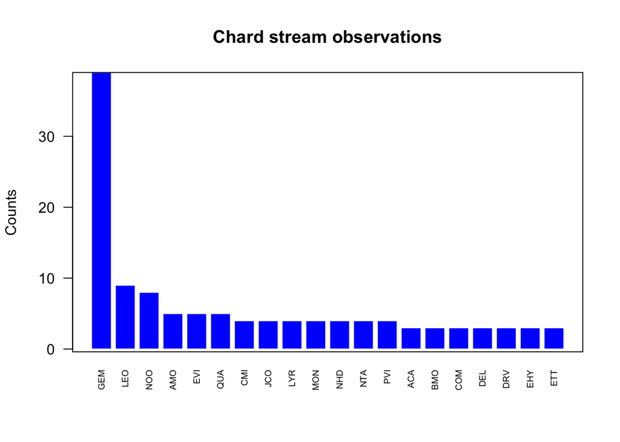

## Fireball activity

Fireballs recorded (Based on IAU definition of apparrent magnitude of -4.0 of greater)

| Datetime | Magnitude | Duration | Stream |
| --- | --- | --- | --- |
| 2016-11-12 23:55:27 | -4.2 | 0.76 | TCA |

The following table shows which stations are generating matched observations with this station and the number of matches:

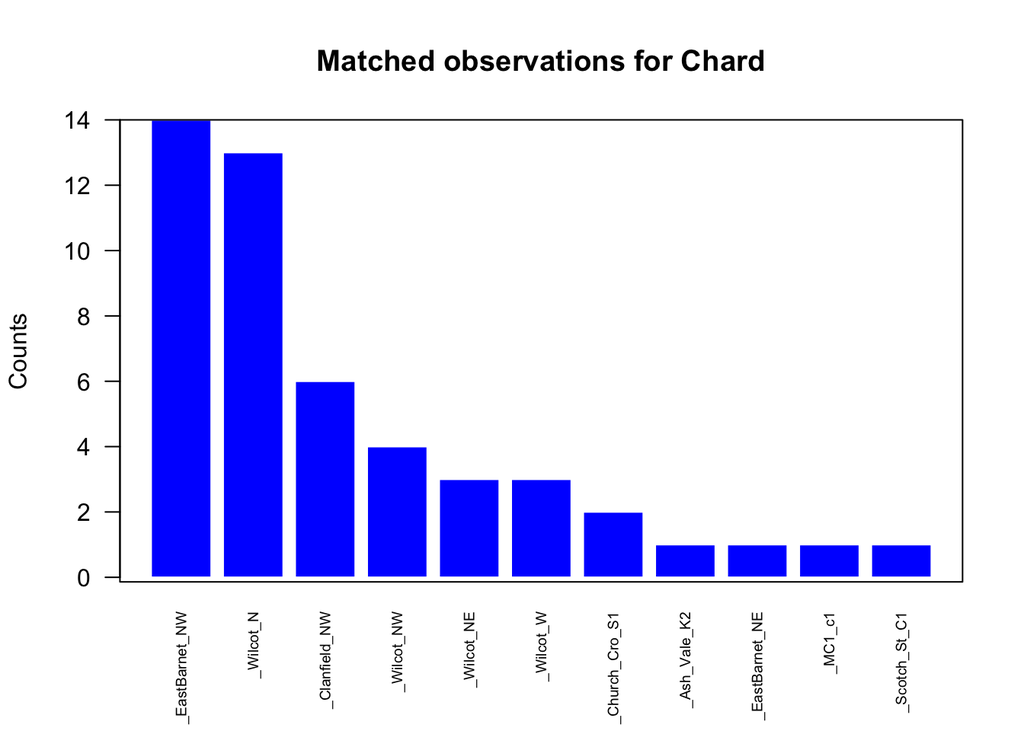

# Detailed counts (including sporadics)

| Shower | Counts |
| --- | --- |
| GEM | 39 |
| SPO | 30 |
| LEO | 9 |
| NOO | 8 |
| AMO | 5 |
| EVI | 5 |
| QUA | 5 |
| CMI | 4 |
| JCO | 4 |
| LYR | 4 |
| MON | 4 |
| NHD | 4 |
| NTA | 4 |
| PVI | 4 |
| ACA | 3 |
| BMO | 3 |
| COM | 3 |
| DEL | 3 |
| DRV | 3 |
| EHY | 3 |
| ETT | 3 |
| MVE | 3 |
| NLM | 3 |
| ORI | 3 |
| RGE | 3 |
| TCE | 3 |
| AAL | 2 |
| AHY | 2 |
| ALO | 2 |
| ASX | 2 |

[output cut: 90 more lines]